# Two Allee mechanisms in one model

A mizer prototype that combines the emergent Allee effect of Van Leeuwen, De Roos & Persson (2008) with cultivation–depensation

Published

November 1, 2026

```r
library(mizer)
library(ggplot2)
options(mizer_info_level = 0)
source("R/build_model.R")
source("R/combined_model.R")

# Results of combined/run_prototype.R and combined/fishing_branches.R
res <- readRDS("combined/results.rds")
scan <- res$scan
intro <- res$intro
fishing <- readRDS("combined/fishing_branches.rds")

col_species <- c(Sprat = "#2a78d6", Cod = "#eb6834")
theme_set(theme_minimal(base_size = 12) +
              theme(panel.grid.minor = element_blank(),
                    legend.position = "top",
                    strip.text = element_text(face = "bold", hjust = 0)))
fmt <- function(x, digits = 2) format(signif(x, digits), big.mark = ",",
                                      scientific = FALSE, trim = TRUE)
#' "min–max" of x with a fixed number of decimals
range_text <- function(x, decimals = 2) {
    paste(sprintf(paste0("%.", decimals, "f"), range(x)), collapse = "–")
}
#' A number with a fixed number of decimals and a proper minus sign
num <- function(x, decimals = 3) {
    sub("^-", "−", sprintf(paste0("%.", decimals, "f"), x))
}
#' The scan result at one grid point
at <- function(w_shift, theta) {
    scan[abs(scan$w_shift - w_shift) < 1e-9 & abs(scan$theta - theta) < 1e-9, ]
}
```

```r
# Size grid of the combined model
p0 <- new_combined_params()
dlnw <- log(w(p0)[2] / w(p0)[1])
# h as mizer would re-derive it for cod eggs of 1 mg
sp_default <- cod_sprat_species
sp_default$w_min <- c(0.001, 0.001)
h_default <- species_params(newMultispeciesParams(
    sp_default, interaction = cod_sprat_interaction,
    info_level = 0))["Cod", "h"]
h_original <- species_params(new_cod_sprat_params())["Cod", "h"]

# Without larval predation the barrier is the food barrier alone
base <- scan[scan$theta == 0, ]
w_food <- approx(base$food, base$w_shift, xout = 1)$y
# Where food alone lets cod invade, the larval predation that restores the
# barrier
theta_inv <- sapply(base$w_shift[base$R0 > 1], function(ws) {
    d <- scan[abs(scan$w_shift - ws) < 1e-9, ]
    approx(d$R0, d$theta, xout = 1)$y
})
anchor_biomass <- at(0.2, 0)$cod_biomass
low_theta <- scan[scan$theta <= 0.02 + 1e-9, ]
unstable <- scan[scan$converged & scan$max_real_part > 0, ]

# Fishing: where the cod state collapses along increasing cod fishing
fb <- fishing$branches
finv <- fishing$invasion
sweeps <- c("Increasing F_cod (from the cod state)",
            "Decreasing F_cod (from the cod-free state + seed)")
abundant <- 0.1
collapse <- do.call(rbind, lapply(finv$F_sprat, function(Fs) {
    up <- fb[fb$F_sprat == Fs & fb$sweep == sweeps[1], ]
    last <- max(up$F_cod[up$Cod > abundant])
    data.frame(F_sprat = Fs, last = last, cod = up$Cod[up$F_cod == last],
               collapse = min(up$F_cod[up$F_cod > last]))
}))
cl0 <- collapse[collapse$F_sprat == 0, ]
cl5 <- collapse[collapse$F_sprat > 0, ]
inv5 <- finv[finv$F_sprat > 0, ]
```

# 1 Summary

Two mechanisms have been proposed for why a collapsed cod stock may not recover, and each has its own mizer model:

- **The emergent Allee effect** of Van Leeuwen et al. (2008), reproduced in How cod shapes its world. Without cod, sprat become a stunted population that produces few young. Juvenile cod then find too few small sprat to grow on.
- **Cultivation–depensation** (Walters and Kitchell 2001), studied in the [cultivation–depensation study](https://github.com/gustavdelius/cultivation-depensation) ([PDF](https://github.com/gustavdelius/cultivation-depensation/blob/main/paper.pdf)). Without cod, abundant adult forage fish eat cod eggs and larvae.

This prototype puts both into one model. It is the cod–sprat model of How cod shapes its world with cod eggs and larvae added, and with sprat eating them. Two parameters move the model continuously from one mechanism to the other:

- the size **`w_shift`** at which cod larvae run out of their own food and come to depend on sprat;
- the strength **θ** with which sprat eat cod eggs and larvae.

The main results:

- **The model runs from one mechanism to the other.** With early diet shifts and no larval predation, only the food barrier keeps cod out of the cod-free state. With late diet shifts, food works *against* the Allee effect and only larval predation keeps cod out. In between, both act.
- **Where both act, they reinforce each other.** Hungry juvenile cod grow slowly, so they spend longer at the sizes where sprat eat them.
- **Simulated cod introductions agree with the invasion analysis.**
- **Fishing.** Under cod fishing the cod state collapses at a fold, and cod do not return when fishing stops. A sprat fishery opens the way back.

The numerics follow the cultivation–depensation study rather than How cod shapes its world: a second-order scheme with size diffusion.

# 2 The model

## 2.1 Changes to the cod–sprat model

`R/combined_model.R` makes three changes to the cod–sprat model of `R/build_model.R`:

- **Cod start as 1 mg eggs** instead of 0.5 g settled juveniles. Their energetics (`h`, `ks`) are those of the original model. Mizer would otherwise re-derive `h` from the new `w_min` and raise it by 9.7 %.
- **Cod larvae feed on an unmodelled larval food** that runs out around the diet-shift size `w_shift`. This is a fixed external encounter rate that gives a feeding level of 0.6 on its own, multiplied by $1/(1 + (w/w_\text{shift})^6)$. Above `w_shift`, cod depend on sprat as before. The larval food is not depleted, so cod larvae do not compete with sprat. That keeps out the third route of the cultivation–depensation study, competition.
- **Sprat eat cod eggs and larvae** with interaction strength θ (`interaction_matrix["Sprat", "Cod"]`). Sprat still do not eat their own larvae, and cod do not eat cod. Those are the asymmetries that cultivation–depensation needs.

## 2.2 Numerics

The numerics follow the cultivation–depensation study, not the original model:

- **Second-order scheme.** 320 size classes ($\Delta \ln w = 0.053$), a centred flux and bin-averaged rates. The larval food and the senescence mortality are bin-averaged by hand.
- **Size diffusion** $D(w) = D_\text{ext} w^{n+1}$, with $D_\text{ext} = c\,(\alpha f_0 h - k_s)$ and $c = 0.1$. A juvenile cohort feeding at $f_0 = 0.6$ then gains 0.1 in the variance of $\ln w$ per unit of $\ln w$ it grows. Since $c > \Delta \ln w$, the centred flux stays monotone.
- **Senescence.** Species grids reach $2 w_\infty$, and a senescence mortality $0.5\,(w/w_\infty)^{10}$ stops diffusion carrying adults beyond $w_\infty$.
- **Time stepping.** Projections use TR-BDF2 with $\Delta t = 0.1$ yr. Steady states come from mizer’s Newton solver and stability from `getStability()`.
- **$R_0$** comes from the steady state of the discretised transport equation itself (`cod_R0()`, ported from `R0_from_rates()` in the cultivation–depensation study). The upwind recursion of `getR0()` in this repository is exact only for the first-order upwind scheme without diffusion; here it is about 3 % low, mostly because of the centred flux.

## 2.3 Anchor states and `erepro`

The two states of the original model (upwind scheme, cod from 0.5 g) are interpolated onto the new grid, with cod eggs and larvae filled in. They are then solved again under the new numerics at the baseline: `w_shift` = 0.2 g and no larval predation (`combined_anchor()`).

The original model folded cod egg and larval survival into `erepro`. That survival is now modelled, so cod `erepro` is recalibrated for every (`w_shift`, θ): it is rescaled until the anchor cod state is a steady state, and Newton’s method then polishes it. This works because with `R_max = Inf` every steady state has $R_0 = 1$, so `erepro` selects the state.

- Across the scan, cod biomass stays within 4 % of the anchor.
- `erepro` ranges from 0.0004 to 0.012.
- The cod-free state does not depend on any cod parameter, so it is the same throughout.

This mirrors the cultivation–depensation study, which held its coexistence state fixed while varying parameters.

Started directly from the anchor, Newton’s method finds a saddle at θ ≥ 0.025 for some values of `w_shift`, with a positive real eigenvalue and up to 30 % less cod. The scan therefore follows the cod state along increasing θ, starting each point from the solution at the previous θ.

# 3 Telling the mechanisms apart

Bistability needs a stable cod state and a cod-free state that cod cannot invade. The cod-free state is uninvadable when the invasion fitness $R_0$ of a rare cod there is below 1. As in the cultivation–depensation study, $R_0$ is decomposed by taking growth and reproduction from one state and mortality from the other. The cod state has $R_0 = 1$.

- **Food**: cod-free growth with cod-state mortality. This is the mechanism of Van Leeuwen et al. (2008), and it is below 1 when juvenile cod starve.
- **Larval predation**: cod-state growth with cod-free mortality. This is cultivation–depensation, and it is below 1 when sprat eat more cod larvae.
- **Interaction** = $R_0$ / (food × larval predation). It lies between 0.74 and 1 here. It is below 1 because hungry juvenile cod grow slowly, so they spend longer in the size range where sprat eat them. The two mechanisms amplify each other.

# 4 Results

## 4.1 The regime map

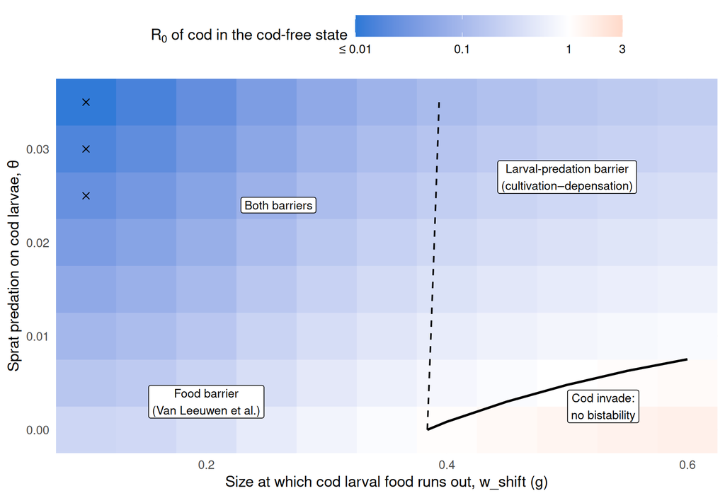

Figure 1: $R_0$ of a rare cod in the cod-free state over the diet-shift size and the strength of larval predation. The solid line is $R_0 = 1$: below and to the right of it cod invade, and elsewhere the system is bistable. The dashed line is where the food factor alone equals 1. × marks an unstable cod state.

```r
# R0 is 0 where the food barrier is absolute; cap the log scale there
map <- scan
map$log_R0 <- pmin(pmax(log10(map$R0), -2), 0.5)
map$log_food <- pmin(pmax(log10(map$food), -2), 0.5)
ggplot(map, aes(w_shift, theta)) +
    geom_raster(aes(fill = log_R0)) +
    geom_contour(aes(z = log_R0), breaks = 0, colour = "black",
                 linewidth = 0.9) +
    geom_contour(aes(z = log_food), breaks = 0, colour = "black",
                 linewidth = 0.6, linetype = "dashed") +
    geom_point(data = unstable, shape = 4, size = 2) +
    annotate("label", x = 0.2, y = 0.003, size = 3.3,
             label = "Food barrier\n(Van Leeuwen et al.)") +
    annotate("label", x = 0.26, y = 0.024, size = 3.3,
             label = "Both barriers") +
    annotate("label", x = 0.5, y = 0.027, size = 3.3,
             label = "Larval-predation barrier\n(cultivation–depensation)") +
    annotate("label", x = 0.53, y = 0.0025, size = 3.3,
             label = "Cod invade:\nno bistability") +
    scale_fill_gradient2(low = "#2a78d6", mid = "white", high = "#eb6834",
                         midpoint = 0, limits = c(-2, 0.5),
                         na.value = "grey80", breaks = c(-2, -1, 0, 0.5),
                         labels = c("≤ 0.01", "0.1", "1", "3"),
                         name = expression(R[0] ~ "of cod in the cod-free state")) +
    scale_x_continuous(expand = c(0, 0)) +
    scale_y_continuous(expand = c(0, 0)) +
    labs(x = "Size at which cod larval food runs out, w_shift (g)",
         y = "Sprat predation on cod larvae, θ") +
    theme(legend.key.width = unit(1.5, "cm"))
```

Figure 1 shows three regions:

- **Food barrier alone** (θ = 0, `w_shift` < 0.38 g).
  - The barrier is not absolute: size diffusion carries some cod through the sizes at which they starve, so $R_0 = 0.27$ at `w_shift` = 0.1 g and 0.37 at 0.2 g.
  - A later diet shift weakens it further ($R_0$ = 0.7 at 0.3 g), and it fails at about 0.38 g.
- **Larval-predation barrier alone** (right of the dashed line, above the solid one).
  - Here food works *against* depensation: a rare cod in the cod-free state grows *better* than in the cod state (food factor 1.06–1.58). This is the situation in the cultivation–depensation study.
  - Larval predation alone keeps $R_0$ below 1, from θ ≈ 0.001–0.008.
- **Both barriers** (left of the dashed line, θ > 0). Both factors are below 1 and multiply.

The cod state is stable at every point with θ ≤ 0.02 (leading real part −0.175 to −0.003/yr). At `w_shift` = 0.1 g it loses stability gradually from θ ≈ 0.025, with a leading real part of +0.005 to +0.016/yr.

```r
pts <- rbind(at(0.2, 0), at(0.3, 0.01), at(0.5, 0), at(0.5, 0.01),
             at(0.5, 0.02))
knitr::kable(data.frame(
    `w_shift (g)` = pts$w_shift,
    θ = pts$theta,
    Food = sprintf("%.2f", pts$food),
    `Larval predation` = sprintf("%.2f", pts$larval_predation),
    Interaction = sprintf("%.2f", pts$interaction),
    R0 = sprintf("**%.2f**", pts$R0),
    `Cod state, max Re (1/yr)` = num(pts$max_real_part),
    check.names = FALSE), align = "rrrrrrr")
```

Table 1: The decomposition of $R_0$ at five points. The cod state has $R_0 = 1$; its leading eigenvalue (max Re) is negative where it is stable.

| w_shift (g) | θ | Food | Larval predation | Interaction | R0 | Cod state, max Re (1/yr) |
| --- | --- | --- | --- | --- | --- | --- |
| 0.2 | 0.00 | 0.37 | 1.00 | 1.00 | **0.37** | −0.095 |
| 0.3 | 0.01 | 0.69 | 0.53 | 0.92 | **0.34** | −0.122 |
| 0.5 | 0.00 | 1.36 | 1.00 | 1.00 | **1.36** | −0.152 |
| 0.5 | 0.01 | 1.35 | 0.56 | 0.96 | **0.72** | −0.175 |
| 0.5 | 0.02 | 1.34 | 0.31 | 0.92 | **0.39** | −0.157 |

## 4.2 Decomposition

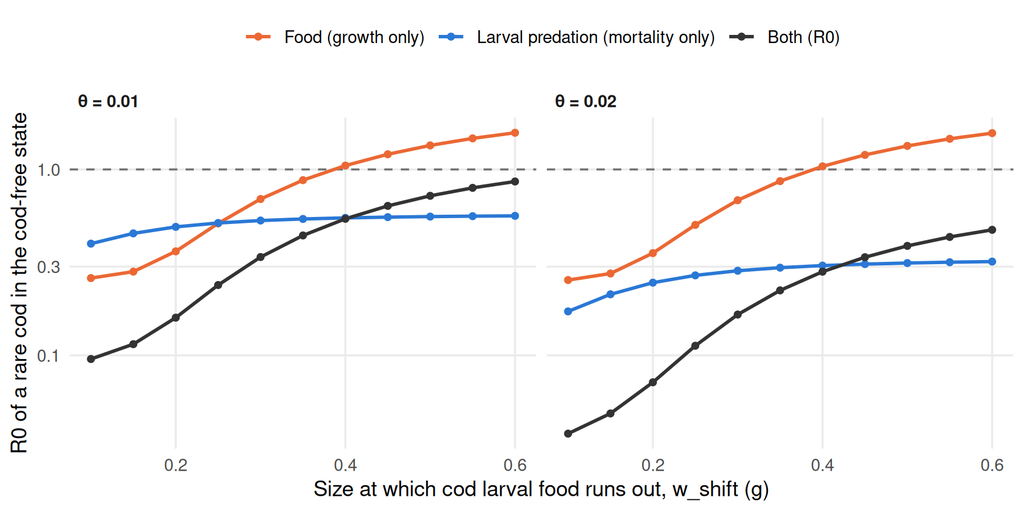

Figure 2: The two factors of $R_0$, and $R_0$ itself, along two values of θ. Where the food factor crosses 1, the barrier passes from shared to purely larval predation.

```r
dec <- scan[scan$theta %in% c(0.01, 0.02) & scan$converged, ]
dec_long <- rbind(
    data.frame(dec[c("w_shift", "theta")], factor = "Food (growth only)",
               value = dec$food),
    data.frame(dec[c("w_shift", "theta")],
               factor = "Larval predation (mortality only)",
               value = dec$larval_predation),
    data.frame(dec[c("w_shift", "theta")], factor = "Both (R0)",
               value = dec$R0))
dec_long$factor <- factor(dec_long$factor, levels = unique(dec_long$factor))
dec_long$theta <- paste("θ =", dec_long$theta)
ggplot(dec_long[dec_long$value > 0, ], aes(w_shift, value, colour = factor)) +
    geom_hline(yintercept = 1, colour = "grey45", linetype = "dashed") +
    geom_line(linewidth = 0.9) +
    geom_point(size = 1.4) +
    facet_wrap(~theta) +
    scale_y_log10() +
    scale_colour_manual(values = c("#eb6834", "#2a78d6", "grey20"),
                        name = NULL) +
    labs(x = "Size at which cod larval food runs out, w_shift (g)",
         y = "R0 of a rare cod in the cod-free state")
```

The food factor rises steeply with `w_shift` (Figure 2). The larval-predation factor is 0.40–0.56 at θ = 0.01 and 0.17–0.32 at θ = 0.02. It is lowest at early diet shifts: there, even in the cod state, juvenile cod grow slowly on sprat and spend longer within reach of sprat.

## 4.3 Introductions

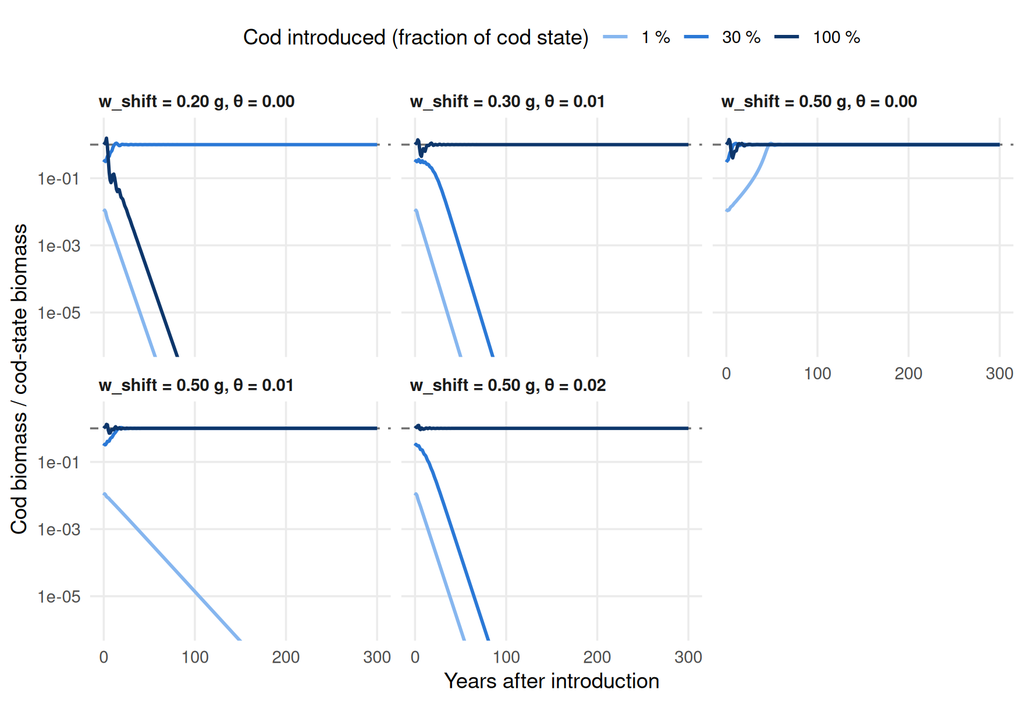

Figure 3: Cod biomass after cod are introduced into the cod-free state at a fraction of the cod state’s size distribution, projected with TR-BDF2.

```r
intro_points <- unique(intro[c("w_shift", "theta")])
point_label <- function(w_shift, theta) {
    sprintf("w_shift = %.2f g, θ = %.2f", w_shift, theta)
}
intro$point <- factor(point_label(intro$w_shift, intro$theta),
                      levels = point_label(intro_points$w_shift,
                                           intro_points$theta))
intro_factors <- sort(unique(intro$factor))
intro$introduced <- factor(paste0(100 * intro$factor, " %"),
                           levels = paste0(100 * intro_factors, " %"))
ggplot(intro, aes(time, cod, colour = introduced)) +
    geom_hline(yintercept = 1, colour = "grey45", linetype = "dashed") +
    geom_line(linewidth = 0.9) +
    facet_wrap(~point, ncol = 3) +
    scale_y_log10() +
    coord_cartesian(ylim = c(1e-6, 3)) +
    scale_colour_manual(values = c("#86b6ef", "#2a78d6", "#0d366b"),
                        name = "Cod introduced (fraction of cod state)") +
    labs(x = "Years after introduction",
         y = "Cod biomass / cod-state biomass")
```

```r
intro_end <- intro[intro$time == max(intro$time), ]
intro_end$outcome <- ifelse(intro_end$cod > 0.5, "establishes", "dies out")
intro_end$outcome[intro_end$outcome == "establishes" &
                      intro_end$factor == min(intro_factors)] <- "invades"
outcomes <- sapply(intro_factors, function(f) {
    d <- intro_end[intro_end$factor == f, ]
    d$outcome[match(point_label(intro_points$w_shift, intro_points$theta),
                    point_label(d$w_shift, d$theta))]
})
colnames(outcomes) <- paste0(100 * intro_factors, " %")
knitr::kable(data.frame(
    `w_shift, θ` = sprintf("%.1f g, %.2f", intro_points$w_shift,
                           intro_points$theta),
    outcomes, check.names = FALSE), row.names = FALSE)
```

Table 2: Outcome of the introductions in Figure 3 after 300 years.

| w_shift, θ | 1 % | 30 % | 100 % |
| --- | --- | --- | --- |
| 0.2 g, 0.00 | dies out | establishes | dies out |
| 0.3 g, 0.01 | dies out | dies out | establishes |
| 0.5 g, 0.00 | invades | establishes | establishes |
| 0.5 g, 0.01 | dies out | establishes | establishes |
| 0.5 g, 0.02 | dies out | dies out | establishes |

The simulations agree with the invasion analysis (Figure 3, Table 2). At `w_shift` = 0.5 g, larval predation creates the bistability that food alone no longer provides, and the Allee threshold rises with θ. Introductions far above the cod state can overshoot: at 0.2 g without larval predation, an introduction of 100 % eats down the sprat, crashes and dies out, although 30 % establishes.

## 4.4 Fishing

This is the analogue of Figure 3 of the cultivation–depensation study, at the point `w_shift` = 0.3 g, θ = 0.01, where both barriers act. Each step projects the model until every biomass changes by less than $10^{-5}$/yr, starting from the state of the previous step.

- **Two sweeps.** Solid lines increase cod fishing from the cod state. Dashed lines decrease it from the cod-free state, with cod topped up to $10^{-6}$ of their unfished abundance before each step.
- **Fishing gear.** Cod fishing is the length-selective trawl of the original model, so $F_\text{cod}$ is the fishing mortality on fully selected cod. The sprat fishery takes sprat above 1 g.

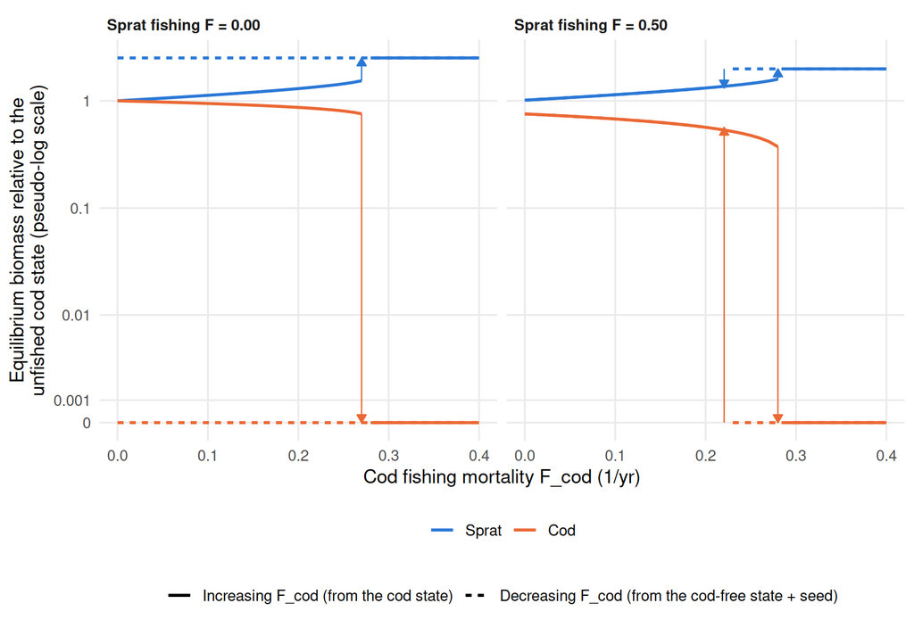

Figure 4: Equilibrium biomass under increasing (solid, from the cod state) and decreasing (dashed, from the cod-free state with a cod seed) cod fishing, without a sprat fishery (left) and with one (right). Biomasses are relative to the unfished cod state. Arrows mark where a branch ends and the system jumps.

```r
branches <- fb
branches$sweep <- factor(branches$sweep, levels = sweeps)
# Near the invasion boundary a cod seed grows so slowly that it has not
# settled after 3000 years. Those steps are not equilibria and are left out.
settled <- branches[branches$converged, ]
# Draw only the branches of steady states, not the jumps between them: each
# sweep is split where cod move between the abundant state and depleted ones
sweep_id <- paste(settled$F_sprat, settled$sweep)
settled$segment <- ave(as.numeric(settled$Cod > abundant), sweep_id,
                       FUN = function(a) cumsum(c(0, diff(a) != 0)))
long <- rbind(
    transform(settled, species = "Sprat", biomass = Sprat),
    transform(settled, species = "Cod", biomass = Cod))
long$species <- factor(long$species, levels = c("Sprat", "Cod"))
long$panel <- sprintf("Sprat fishing F = %.2f", long$F_sprat)
# A vertical arrow at the end of each branch to the state the system jumps to
jumps <- do.call(rbind, lapply(
    split(long, paste(long$species, long$panel, long$sweep)),
    function(d) {
        k <- which(diff(d$segment) != 0)
        data.frame(d[k, c("F_cod", "F_sprat", "sweep", "panel", "species")],
                   y = d$biomass[k], yend = d$biomass[k + 1])
    }))
# Where a cod seed invades, the jump happens at the invasion boundary
inv <- finv$F_inv[match(jumps$F_sprat, finv$F_sprat)]
at_inv <- jumps$sweep == sweeps[2] & !is.na(inv)
jumps$F_cod[at_inv] <- inv[at_inv]
ggplot(long, aes(F_cod, biomass, colour = species)) +
    geom_line(aes(linetype = sweep,
                  group = interaction(species, sweep, segment)),
              linewidth = 0.9) +
    geom_segment(data = jumps,
                 aes(x = F_cod, xend = F_cod, y = y, yend = yend),
                 linewidth = 0.4, show.legend = FALSE,
                 arrow = arrow(length = unit(2, "mm"), type = "closed")) +
    facet_wrap(~panel) +
    scale_y_continuous(trans = scales::pseudo_log_trans(sigma = 1e-3),
                       breaks = c(0, 1e-3, 1e-2, 0.1, 1),
                       labels = c("0", "0.001", "0.01", "0.1", "1")) +
    scale_colour_manual(values = col_species) +
    labs(x = "Cod fishing mortality F_cod (1/yr)",
         y = "Equilibrium biomass relative to the\nunfished cod state (pseudo-log scale)",
         colour = NULL, linetype = NULL) +
    # Species above branch type: without explicit orders the two legends
    # swapped places between renders
    guides(colour = guide_legend(order = 1),
           linetype = guide_legend(order = 2)) +
    theme(legend.position = "bottom", legend.box = "vertical")
```

The two panels of Figure 4:

- **Without sprat fishing**, the cod state persists up to $F_\text{cod}$ = 0.27, with cod at 76 % of their unfished biomass, and collapses at 0.28. The cod-free state cannot be invaded at any $F_\text{cod}$ ($R_0$ = 0.34 at $F_\text{cod}$ = 0). Reducing fishing after the collapse does not bring cod back.
- **With sprat fishing at F = 0.5**, the cod state collapses at 0.29, where cod are already down to 37 % of their unfished biomass. The sprat fishery makes the cod-free state invadable ($R_0$ = 1.37 at $F_\text{cod}$ = 0). Below $F_\text{inv}$ = 0.22, a cod seed invades and returns to the abundant state. The hysteresis loop narrows to 0.22–0.28.

Two differences from Figure 3 of the cultivation–depensation study:

- **Sprat fishing barely moves the collapse threshold** (0.28 to 0.29). In the cultivation–depensation study, forage-fish harvest moves it from 0.16 to 0.25. Here it mainly opens the way back.
- **There is no low-abundance cod state.** In the cultivation–depensation study, a predator invading under forage harvest first settles at low abundance, and full recovery needs more forage harvest. Here the invader goes straight back to the abundant state. The likely reason is the food mechanism: once established, cod thin the sprat, which raises sprat recruitment and feeds juvenile cod. The predator of the cultivation–depensation study lacks this feedback, because there food works against depensation.

Two steps of the downward sweep with sprat fishing, $F_\text{cod}$ = 0.21 and 0.22, are left out. There $R_0$ is within a few per cent of 1, and the seed had not settled after 3000 years. The return arrow is drawn at $F_\text{inv}$, where $R_0 = 1$.

The settling uses mizer’s Euler method with $\Delta t = 0.1$. The cultivation–depensation study settles with $\Delta t = 0.5$, but in this model that step is unstable: Euler’s one-step map has a spectral radius of 1.08 in the cod-free state. TR-BDF2 with $\Delta t = 0.5$ drifts away from a stable cod state after about 150 years.

# 5 Effect of the numerics

The first version of this prototype ([commit 161199e](https://github.com/gustavdelius/how_cod_shapes_its_world/commit/161199e)) used the numerics of the original model: upwind scheme, 150 size classes and no physical diffusion. The qualitative result is the same, but three things changed:

- **The food barrier now leaks.** Under upwind, growth stopped at about 0.4 g in the cod-free state, and $R_0$ was exactly 0 up to `w_shift` = 0.2 g. With diffusion that does not depend on food, as in the cultivation–depensation study, cod diffuse across the sizes at which they starve. Whether starving fish should keep the growth variability of well-fed ones is debatable: this choice weakens the mechanism of Van Leeuwen et al. (2008).
- **The food barrier fails earlier**, at `w_shift` ≈ 0.38 g instead of 0.46 g.
- **The cod state is much more stable.**
  - At the baseline the leading real part is −0.095/yr instead of −0.060/yr.
  - Under upwind, the cod state cycled for `w_shift` ≥ 0.65 g without larval predation. Here it is a stable fixed point up to 0.6 g.
  - Under upwind, an introduction of 30 % failed at `w_shift` = 0.2 g, θ = 0. Here it establishes.

# 6 Caveats

- **Larval predation is scanned only up to θ = 0.035.** In the upwind version the cod state reached a fold near θ ≈ 0.04, where the Allee threshold meets the cod state. That has not been checked under the new numerics.
- **Basins can be small.** Introductions far above the cod state can overshoot and die out (Table 2). Stability is therefore checked with Newton’s method and `getStability()`, not by projection.
- **What sprat eat.** Sprat use their planktivore kernel (β = 1000) on cod larvae, so they hit eggs and the smallest larvae hardest. Juvenile sprat, which are more numerous in the cod state, eat cod eggs too. This partly offsets the effect of the adults.
- **Simplifications.**
  - The larval food of cod is fixed, so the competition route is left out.
  - The recalibrated `erepro` ties every point to the original cod state.
  - The size diffusion does not depend on how well fish feed.
  - The $R_0$ calculation calls mizer internals, as in the cultivation–depensation study, and was written against mizer 3.4.0.9001.

# 7 Possible next steps

- The fishing thresholds across (`w_shift`, θ): does the collapse threshold or the width of the hysteresis loop depend on which barrier holds cod back? Figure 4 covers one point only.
- Sensitivity to sprat cannibalism, which removes the barrier in the cultivation–depensation study above $\theta_\text{For,For} \approx 0.12$.
- Competition: let cod larvae eat the plankton spectrum instead of a fixed larval food.
- Size diffusion that scales with growth, so that starving fish do not diffuse through the food bottleneck.

# 8 Reproducing this document

| File | Contents |
| --- | --- |
| `R/combined_model.R` | The combined model, the anchor states, $R_0$ and its decomposition |
| `combined/run_prototype.R` | The scan over (`w_shift`, θ) and the introductions; writes `combined/results.rds` |
| `combined/fishing_branches.R` | The branches under cod fishing; writes `combined/fishing_branches.rds` |
| `combined_model.qmd` | This document; it reads the two results files |

```bash
OPENBLAS_NUM_THREADS=1 OMP_NUM_THREADS=1 Rscript combined/run_prototype.R
OPENBLAS_NUM_THREADS=1 OMP_NUM_THREADS=1 Rscript combined/fishing_branches.R
quarto render combined_model.qmd
```

The scan takes about an hour on 8 cores and the fishing branches about 15 minutes on 4 cores. Limiting BLAS to one thread per worker matters: otherwise the threads of the parallel workers compete. The document itself renders in seconds and writes `docs/combined_model.html`.

The results were computed with mizer 3.4.0.9001. This document was rendered with mizer 3.4.0.9001 and R version 4.6.2 (2026-10-29).

# References

Van Leeuwen, Anieke, André M. De Roos, and Lennart Persson. 2008. “How Cod Shapes Its World.” *Journal of Sea Research* 60 (1-2): 89–104. https://doi.org/10.1016/j.seares.2008.02.008.

Walters, Carl, and James F. Kitchell. 2001. “Cultivation/Depensation Effects on Juvenile Survival and Recruitment: Implications for the Theory of Fishing.” *Canadian Journal of Fisheries and Aquatic Sciences* 58 (1): 39–50. https://doi.org/10.1139/f00-160.